# • DOMAIN: Semiconductor manufacturing process

**• CONTEXT: A complex modern semiconductor manufacturing process is normally under constant surveillance via the monitoring of signals/ variables collected from sensors and or process measurement points. However, not all of these signals are equally valuable in a specific monitoring system. The measured signals contain a combination of useful information, irrelevant information as well as noise. Engineers typically have a much larger number of signals than are actually required. If we consider each type of signal as a feature, then feature selection may be applied to identify the most relevant signals. The Process Engineers may then use these signals to determine key factors contributing to yield excursions downstream in the process. This will enable an increase in process throughput, decreased time to learning and reduce the per unit production costs. These signals can be used as features to predict the yield type. And by analysing and trying out different combinations of features, essential signals that are impacting the yield type can be identified.**

**• DATA DESCRIPTION: sensor-data.csv : (1567, 592) The data consists of 1567 examples each with 591 features. The dataset presented in this case represents a selection of such features where each example represents a single production entity with associated measured features and the labels represent a simple pass/fail yield for in house line testing. Target column “ –1” corresponds to a pass and “1” corresponds to a fail and the data time stamp is for that specific test point.**

**• PROJECT OBJECTIVE: We will build a classifier to predict the Pass/Fail yield of a particular process entity and analyse whether all the features are required to build the model or not.**

# Import and explore the data.

```python
import pandas as pd
import os
import numpy as np
from statsmodels.stats.outliers_influence import variance_inflation_factor
from scipy.stats import zscore
import matplotlib.pyplot as plt
from sklearn.preprocessing import StandardScaler
from sklearn.model_selection import train_test_split
import pandas as pd
import os
import numpy as np
import seaborn as sns
import matplotlib.pyplot as plt
from sklearn.preprocessing import StandardScaler,LabelEncoder
from scipy import stats
%matplotlib inline
sns.set_style('darkgrid')
%matplotlib inline
from sklearn.preprocessing import MinMaxScaler
from scipy.stats import zscore
from sklearn.model_selection import train_test_split
from sklearn.neighbors import KNeighborsClassifier
from sklearn.metrics import accuracy_score, confusion_matrix,f1_score
from sklearn.linear_model import LogisticRegression
from sklearn.tree import DecisionTreeClassifier
from sklearn.metrics import classification_report
from sklearn import model_selection
import warnings
warnings.filterwarnings("ignore")
from sklearn.ensemble import BaggingClassifier
from sklearn.ensemble import RandomForestClassifier
from sklearn.ensemble import GradientBoostingClassifier
from sklearn.ensemble import AdaBoostClassifier
from statistics import mean
import pickle
from sklearn.neighbors import KNeighborsClassifier
from imblearn.over_sampling import SMOTE
from sklearn.model_selection import GridSearchCV
from sklearn.metrics import roc_auc_score
from sklearn.preprocessing import FunctionTransformer
```

```python
os.chdir('C:\\Users\\VGopalak\\Desktop\\ML\\FMT Project')
```

**Reading Dataset**

```python
df=pd.read_csv('signal-data.csv')
```

```python
df.columns = df.columns.to_series().apply(lambda x: x.strip())
```

```python
df_copy=df.copy()
```

```python
df.head()
```

|  | Time | 0 | 1 | 2 | 3 | 4 | 5 | 6 | 7 | 8 | ... | 581 | 582 | 583 | 584 | 585 | 586 | 587 | 588 | 589 | Pass/Fail |
| --- | --- | --- | --- | --- | --- | --- | --- | --- | --- | --- | --- | --- | --- | --- | --- | --- | --- | --- | --- | --- | --- |
| 0 | 2008-07-19 11:55:00 | 3030.93 | 2564.00 | 2187.7333 | 1411.1265 | 1.3602 | 100.0 | 97.6133 | 0.1242 | 1.5005 | ... | NaN | 0.5005 | 0.0118 | 0.0035 | 2.3630 | NaN | NaN | NaN | NaN | -1 |
| 1 | 2008-07-19 12:32:00 | 3095.78 | 2465.14 | 2230.4222 | 1463.6606 | 0.8294 | 100.0 | 102.3433 | 0.1247 | 1.4966 | ... | 208.2045 | 0.5019 | 0.0223 | 0.0055 | 4.4447 | 0.0096 | 0.0201 | 0.0060 | 208.2045 | -1 |
| 2 | 2008-07-19 13:17:00 | 2932.61 | 2559.94 | 2186.4111 | 1698.0172 | 1.5102 | 100.0 | 95.4878 | 0.1241 | 1.4436 | ... | 82.8602 | 0.4958 | 0.0157 | 0.0039 | 3.1745 | 0.0584 | 0.0484 | 0.0148 | 82.8602 | 1 |
| 3 | 2008-07-19 14:43:00 | 2988.72 | 2479.90 | 2199.0333 | 909.7926 | 1.3204 | 100.0 | 104.2367 | 0.1217 | 1.4882 | ... | 73.8432 | 0.4990 | 0.0103 | 0.0025 | 2.0544 | 0.0202 | 0.0149 | 0.0044 | 73.8432 | -1 |
| 4 | 2008-07-19 15:22:00 | 3032.24 | 2502.87 | 2233.3667 | 1326.5200 | 1.5334 | 100.0 | 100.3967 | 0.1235 | 1.5031 | ... | NaN | 0.4800 | 0.4766 | 0.1045 | 99.3032 | 0.0202 | 0.0149 | 0.0044 | 73.8432 | -1 |

5 rows × 592 columns

```python
df.shape
```

```
(1567, 592)
```

# Missing Value Treatment.

```python
#missing value function
def missing_data(data):
    total = data.isnull().sum()
    percent = (data.isnull().sum()/data.isnull().count()*100)
    tt = pd.concat([total, percent], axis=1, keys=['Total', 'Percent'])
    types = []
    for col in data.columns:
        dtype = str(data[col].dtype)
        types.append(dtype)
    tt['Types'] = types
    return tt
```

```python
missing_data(df)[missing_data(df)['Percent']>=80]['Percent'].sort_values(ascending=False)
```

```
157    91.193363
158    91.193363
292    91.193363
293    91.193363
85     85.577537
220    85.577537
358    85.577537
492    85.577537
Name: Percent, dtype: float64
```

**Dropping Features which has more than 85% of missing values.**

```python
df_1=df[df.columns[df.isnull().mean() <= 0.85]]
```

**As these values are corresponds to test results replacing all NaN values with 0. 0 repsresnts absence of signals.**

```python
df_1 = df_1.replace(np.NaN, 0)
```

```python
df_1.isnull().any().any()
```

```
False
```

**All null values are replaced with zero.**

**Dropping time column**

```python
df_1.select_dtypes(include='object').columns
#df_1.dtypes=='object'[:1]
```

```
Index(['Time'], dtype='object')
```

```python
df_1.drop('Time',axis=1,inplace=True)
```

# Unique Columns.

**Dropping Features which has unique records.**

```python
df_1=df_1[df_1.columns[df_1.nunique()>1]]
```

# Data Analysis & Visualisation

**Using VIF we can remove multi collinear columns.**

# VIF

```python
X = df_1.iloc[:,:-1]
```

```python
def calculate_vif_(x, thresh=5.0):
    variables = list(range(x.shape[1]))
    dropped = True
    while dropped:
        dropped = False
        vif = [variance_inflation_factor(x.iloc[:, variables].values, ix)
               for ix in range(x.iloc[:, variables].shape[1])]

        maxloc = vif.index(max(vif))
        if max(vif) > thresh:
            print('dropping \'' + x.iloc[:, variables].columns[maxloc] +
                  '\' at index: ' + str(maxloc))
            del variables[maxloc]
            dropped = True
    print('Remaining variables:')
    print(x.columns[variables])
    return x.iloc[:, variables]
```

```python
calculate_vif_(X, thresh=5.0)
```

```
dropping '42' at index: 41
dropping '74' at index: 71
dropping '206' at index: 187
dropping '209' at index: 189
dropping '342' at index: 281
dropping '347' at index: 285
dropping '70' at index: 67
dropping '50' at index: 48
dropping '174' at index: 162
dropping '275' at index: 225
dropping '309' at index: 254
dropping '46' at index: 44
dropping '172' at index: 159
dropping '37' at index: 36
dropping '69' at index: 63
dropping '518' at index: 394
dropping '204' at index: 178
dropping '66' at index: 60
dropping '121' at index: 109
dropping '148' at index: 134
dropping '49' at index: 45
dropping '447' at index: 344
dropping '187' at index: 163
dropping '152' at index: 135
dropping '469' at index: 353
dropping '124' at index: 110
dropping '173' at index: 151
dropping '244' at index: 192
dropping '56' at index: 49
dropping '53' at index: 46
dropping '420' at index: 311
dropping '183' at index: 155
dropping '540' at index: 388
dropping '34' at index: 33
dropping '411' at index: 301
dropping '45' at index: 41
dropping '252' at index: 194
dropping '516' at index: 372
dropping '175' at index: 147
dropping '180' at index: 149
```

[output cut: 334 more lines]

```
dropping '408' at index: 54
dropping '144' at index: 30
dropping '324' at index: 41
dropping '491' at index: 74
Remaining variables:
Index(['9', '10', '24', '41', '59', '72', '75', '76', '77', '78', '79', '80',
       '81', '82', '91', '94', '95', '100', '101', '102', '104', '105', '106',
       '107', '108', '110', '112', '114', '129', '140', '151', '162', '195',
       '198', '214', '290', '294', '295', '296', '306', '312', '340', '346',
       '350', '351', '355', '360', '362', '367', '382', '385', '390', '412',
       '418', '419', '425', '426', '429', '432', '433', '435', '438', '457',
       '468', '476', '478', '482', '483', '484', '485', '486', '487', '488',
       '489', '499', '500', '510', '511', '520', '521', '523', '525', '526',
       '552', '554', '560', '567', '574', '578', '581', '583', '589'],
      dtype='object')
```

|  | 9 | 10 | 24 | 41 | 59 | 72 | 75 | 76 | 77 | 78 | ... | 526 | 552 | 554 | 560 | 567 | 574 | 578 | 581 | 583 | 589 |
| --- | --- | --- | --- | --- | --- | --- | --- | --- | --- | --- | --- | --- | --- | --- | --- | --- | --- | --- | --- | --- | --- |
| 0 | 0.0162 | -0.0034 | 751.00 | 4.515 | -1.7264 | 0.0000 | 0.0126 | -0.0206 | 0.0141 | -0.0307 | ... | 0.5064 | 0.1827 | 0.3363 | 0.1039 | 0.0000 | 3.0624 | 0.0000 | 0.0000 | 0.0118 | 0.0000 |
| 1 | -0.0005 | -0.0148 | -1640.25 | 2.773 | 0.8073 | 0.0000 | -0.0039 | -0.0198 | 0.0004 | -0.0440 | ... | 0.8832 | 0.2829 | 0.4989 | 0.0375 | 0.0000 | 2.0111 | 0.0096 | 208.2045 | 0.0223 | 208.2045 |
| 2 | 0.0041 | 0.0013 | -1916.50 | 5.434 | 23.8245 | 140.6972 | -0.0078 | -0.0326 | -0.0052 | 0.0213 | ... | 0.6451 | 0.0857 | 0.3752 | 0.1233 | 0.2562 | 4.0923 | 0.0584 | 82.8602 | 0.0157 | 82.8602 |
| 3 | -0.0124 | -0.0033 | -1657.25 | 1.279 | 24.3791 | 160.3210 | -0.0555 | -0.0461 | -0.0400 | 0.0400 | ... | 0.7404 | 0.6812 | 17.4781 | 0.2710 | 0.0670 | 2.8971 | 0.0202 | 73.8432 | 0.0103 | 73.8432 |
| 4 | -0.0031 | -0.0072 | 117.00 | 2.209 | -12.2945 | 0.0000 | -0.0534 | 0.0183 | -0.0167 | -0.0449 | ... | 2.2181 | 0.4287 | 0.8311 | 0.0461 | 0.0000 | 3.1776 | 0.0000 | 0.0000 | 0.4766 | 73.8432 |
| ... | ... | ... | ... | ... | ... | ... | ... | ... | ... | ... | ... | ... | ... | ... | ... | ... | ... | ... | ... | ... | ... |
| 1562 | -0.0045 | -0.0057 | 356.00 | 1.427 | 2.8182 | 0.0000 | 0.0000 | 0.0000 | 0.0000 | 0.0000 | ... | 1.2587 | 0.4754 | 0.3141 | 0.0929 | 0.0382 | 2.6401 | 0.0068 | 203.1720 | 0.0143 | 203.1720 |
| 1563 | -0.0061 | -0.0093 | 339.00 | 2.945 | -3.3555 | 158.7832 | 0.0000 | 0.0000 | 0.0000 | 0.0000 | ... | 0.4512 | 0.0949 | 0.5058 | 0.0696 | 0.0495 | 1.9077 | 0.0000 | 0.0000 | 0.0131 | 203.1720 |
| 1564 | 0.0000 | 0.0000 | -1226.00 | 2.863 | 1.1664 | 0.0000 | 0.0000 | 0.0000 | 0.0000 | 0.0000 | ... | 0.4867 | 0.2829 | 0.5605 | 0.0332 | 0.0965 | 2.1760 | 0.0197 | 43.5231 | 0.0153 | 43.5231 |
| 1565 | -0.0072 | 0.0032 | 394.75 | 2.067 | 4.4682 | 0.0000 | 0.0000 | 0.0000 | 0.0000 | 0.0000 | ... | 0.3866 | 0.0949 | 0.5058 | 0.0435 | 0.0382 | 3.2524 | 0.0262 | 93.4941 | 0.0178 | 93.4941 |
| 1566 | 0.0000 | 0.0000 | -425.00 | 2.741 | 1.8718 | 0.0000 | 0.0000 | 0.0000 | 0.0000 | 0.0000 | ... | 1.5629 | 0.0949 | 0.5058 | 0.0678 | 0.0493 | 2.2727 | 0.0117 | 137.7844 | 0.0181 | 137.7844 |

1567 rows × 92 columns

**Selcting only VIF selected columns**

```python
df=df_1[['9', '10', '24', '41', '59', '72', '75', '76', '77', '78', '79', '80',
       '81', '82', '91', '94', '95', '100', '101', '102', '104', '105', '106',
       '107', '108', '110', '112', '114', '129', '140', '151', '162', '195',
       '198', '214', '290', '294', '295', '296', '306', '312', '340', '346',
       '350', '351', '355', '360', '362', '367', '382', '385', '390', '412',
       '418', '419', '425', '426', '429', '432', '433', '435', '438', '457',
       '468', '476', '478', '482', '483', '484', '485', '486', '487', '488',
       '489', '499', '500', '510', '511', '520', '521', '523', '525', '526',
       '552', '554', '560', '567', '574', '578', '581', '583', '589','Pass/Fail']]
```

```python
df.shape
```

```
(1567, 93)
```

**Now we have 1567 rows and 93 columns.**

**Distribution of Target Varibale.**

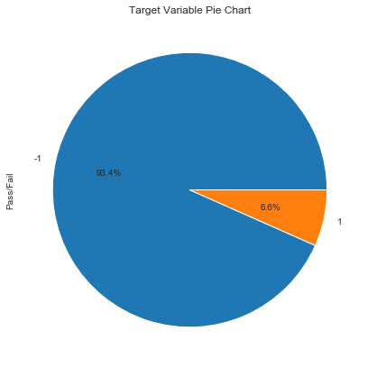

```python
f,axes=plt.subplots(1,1,figsize=(17,7))
df['Pass/Fail'].value_counts().plot.pie(autopct='%1.1f%%')
axes.set_title('Target Variable Pie Chart')
plt.show()
```

- **It is evident that there is imbalance in the dataset.**
- **Only 6.6% represents the fail category.**

**Seperating failures and passes .**

```python
passes = df.loc[df['Pass/Fail']==-1]
fails  = df.loc[df['Pass/Fail']== 1]
```

```python
plt.style.use('seaborn')
def plot_row(df, rows=0, show_nans=False, figsize=None, alpha=1.):
    if figsize is not None:
        fig = plt.figure(figsize=(figsize))
    if type(rows) == int:
        rows = [rows]
    for row in rows:
        row = df.values[row][:]
        if show_nans:
            nans = np.where(pd.isnull(row))
            ymax,ymin = max(row)/5, -max(row)/5
            plt.vlines(nans, ymin=ymin, ymax=ymax, linewidth=.5, color='firebrick')
        plt.plot(range(len(row)), row, alpha=alpha);
```

**Plotting First Row**

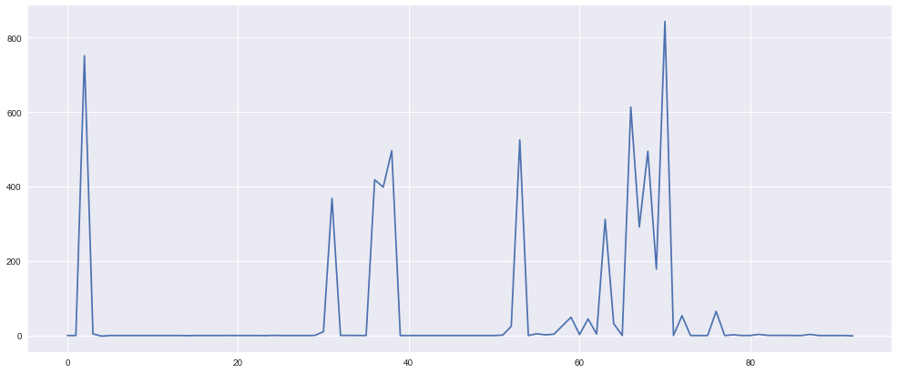

```python
plot_row(df, figsize=(17,7), show_nans=True)
```

**50 random signals:**

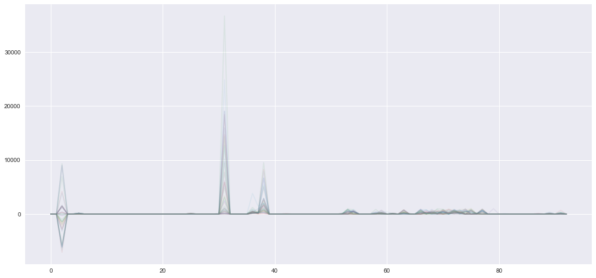

```python
plot_row(df, np.random.randint(len(df), size=50), figsize=(17,8), alpha=0.1)
```

**All Fails-104 signals**

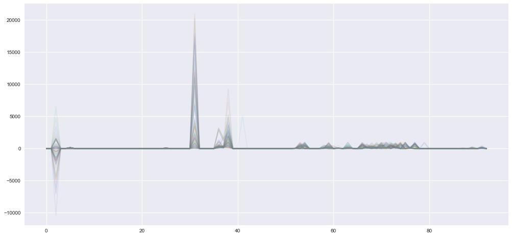

```python
plot_row(fails, rows=range(len(fails)), figsize=(17,8), alpha=0.1)
```

**Random 100 passes**

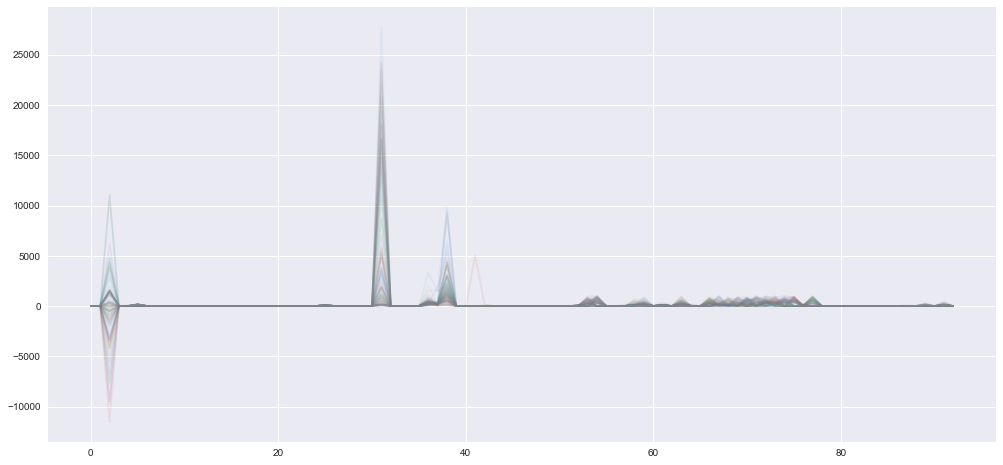

```python
plot_row(passes, rows=np.random.randint(len(passes), size=100), figsize=(17,8), alpha=0.1)
```

- **Data Visualization isn't going to work.**
- **Since large number of signal columns deriving insights through visualization is challenging.**

# Data Preprocessing.

```python
def pre_process(df):
    df=df.iloc[:,[8, 9, 23, 40, 58, 71, 74,75, 76, 77, 78, 79,
       80, 81, 90, 93, 94, 99, 100, 101, 103, 104, 105,
       106, 107, 109, 111, 113, 128, 139, 150, 161, 194,
       197, 213, 289, 295, 305, 311, 339, 345,
       349, 350, 354, 361, 366, 381, 384, 389, 411,
       417,418, 424, 425, 428, 431, 432, 434, 437, 456,
       467, 475,481, 482, 483, 484, 485, 486, 487,
       488, 498, 499, 509, 510, 519, 520, 522, 524, 525,
       551, 553, 559, 566, 573, 577, 580, 582, 588]]

    #df=df[df.columns[df.isnull().mean() <= 0.85]]
    df = df.replace(np.NaN, 0)
    #df.drop('Time',axis=1,inplace=True)
    #df=df[df.columns[df.nunique()>1]]

    return df
```

**Scaling Numerical columns**

```python
num_col=list(df.columns)
num_col.remove('Pass/Fail')
```

```python
std = StandardScaler()
scaled = std.fit_transform(df[num_col])
X_scaled = pd.DataFrame(scaled,columns=num_col)
```

**Problems in Imbalance Target**

**If the imbalanced data is not treated beforehand, then this will degrade the performance of the classifier model. Most of the predictions will correspond to the majority class and treat the minority class features as noise in the data and ignore them. This will result in a high bias in the model**

```python
X = df.iloc[:,:-1]
```

```python
X.shape
```

```
(1567, 92)
```

```python
y=df['Pass/Fail']
```

**Building model without sampling**

# Train - Test Split

```python
# Split X and y into training and test set in 70:30 ratio
X_train, X_test, y_train, y_test = train_test_split(X, y, test_size=0.30, random_state=1)
```

```python
print('x_train shape:' , X_train.shape)
print('x_test shape:' , X_test.shape)
print('y_train shape:' , y_train.shape)
print('y_test shape:' , y_test.shape)
```

[output not shown]

**Checking if the train and test data have similar statistical characteristics when compared with original data.**

**Does the mean of original data differ significantly from train/test data?**

**H0: The mean of original and Train/Test Data are same.**

**H1: The mean of original and Train/Test Data are significantly different.**

```python
def test_stats(sample1,sample2):
    from scipy import stats
    stats,p_value=stats.ttest_ind(sample1,sample2,axis=0,equal_var=False)
    if p_value.all()<0.05:
        print('Reject Null Hypothesis.The means of original and train/test data are significantly different.')
    else:
        print('Fail to reject Null Hypothesis.The means of original and train/test data are same')
```

```python
print("Comparing X and X_train")
test_stats(X,X_train)
print("")

print("Comparing X and X_test")
test_stats(X,X_train)
print("")


print("Comparing y and y_train")
test_stats(y,y_train)
print("")


print("Comparing y and y_test")
test_stats(y,y_test)
print("")
```

```
Comparing X and X_train
Fail to reject Null Hypothesis.The means of original and train/test data are same

Comparing X and X_test
Fail to reject Null Hypothesis.The means of original and train/test data are same

Comparing y and y_train
Fail to reject Null Hypothesis.The means of original and train/test data are same

Comparing y and y_test
Fail to reject Null Hypothesis.The means of original and train/test data are same
```

# Model training, testing and tuning

# **Decision Tree**

```python
pipe_DT = Pipeline([('scl', StandardScaler()), ('DT', DecisionTreeClassifier(random_state=1,criterion='entropy'))])
pipe_DT.fit(X_train, y_train)
print('Train Accuracy: %.3f' % pipe_DT.score(X_train, y_train))
print('Test Accuracy: %.3f' % pipe_DT.score(X_test, y_test))
```

```
Train Accuracy: 1.000
Test Accuracy: 0.896
```

```python
y_pred = pipe_DT.predict(X_test)
print(classification_report(y_test, y_pred))
```

```
              precision    recall  f1-score   support

          -1       0.94      0.96      0.95       439
           1       0.21      0.16      0.18        32

    accuracy                           0.90       471
   macro avg       0.57      0.56      0.56       471
weighted avg       0.89      0.90      0.90       471
```

- **There is high accuracy in training data and less accuracy in test data.**
- **This result is purely due to overfitting.**
- **Smote and Grid search to find optimal paramters will improve the model.**

# SMOTE

**Creating objects for scaling,smote and decision tree.**

```python
from imblearn.pipeline import make_pipeline
scl=StandardScaler()
smote=SMOTE(random_state=1)
DT=DecisionTreeClassifier(random_state=1)
```

```python
get_df = FunctionTransformer(pre_process, validate=False)
```

**Creating Pipeline**

```python
pipe_DT = make_pipeline(scl, smote, DT)
parameter={'decisiontreeclassifier__max_depth':np.arange(1,5),'decisiontreeclassifier__criterion':['entropy','gini'],
          'decisiontreeclassifier__max_features':np.arange(1,10),'decisiontreeclassifier__min_samples_leaf':np.arange(1,5)
           #,'max_leaf_nodes':np.arange(2,20)
          }
```

# Grid Search CV

**Using Grid search to get best parametrs**

```python
grid = GridSearchCV( pipe_DT , param_grid = parameter,scoring='f1', cv = 5)
grid.fit( X_train, y_train)
print(" Best cross-validation accuracy: {:.2f}". format( grid.best_score_))
print(" Best parameters: ", grid.best_params_)
print(" Test set accuracy: {:.2f}". format( grid.score( X_test, y_test)))
```

```
 Best cross-validation accuracy: 0.18
 Best parameters:  {'decisiontreeclassifier__criterion': 'entropy', 'decisiontreeclassifier__max_depth': 1, 'decisiontreeclassifier__max_features': 1, 'decisiontreeclassifier__min_samples_leaf': 1}
 Test set accuracy: 0.19
```

**Creating model with best parameters**

```python
scl=StandardScaler()
smote=SMOTE(random_state=1)
DT=DecisionTreeClassifier(random_state=1,criterion='entropy',max_depth=1,max_features=1,min_samples_leaf=1)
pipe_DT = make_pipeline(scl, smote, DT)
pipe_DT.fit(X_train, y_train)
y_pred = pipe_DT.predict(X_test)
print('Train Accuracy: %.3f' % pipe_DT.score(X_train, y_train))
print('Test Accuracy: %.3f' % pipe_DT.score(X_test, y_test))
print(classification_report(y_test, y_pred))
```

```
Train Accuracy: 0.727
Test Accuracy: 0.694
              precision    recall  f1-score   support

          -1       0.95      0.71      0.81       439
           1       0.12      0.53      0.19        32

    accuracy                           0.69       471
   macro avg       0.54      0.62      0.50       471
weighted avg       0.90      0.69      0.77       471
```

- **Now Decision tree getting balanced training and testing accuracy.**
- **Both Grid search and smote helped to achieve this.**
- **The precision value is low compared to other class. Recall is bt improved**

# **Random Search CV**

```python
from sklearn.model_selection import RandomizedSearchCV
parameter={'decisiontreeclassifier__max_depth':np.arange(1,5),'decisiontreeclassifier__criterion':['entropy','gini'],
          'decisiontreeclassifier__max_features':np.arange(1,10),'decisiontreeclassifier__min_samples_leaf':np.arange(1,5)
           #,'max_leaf_nodes':np.arange(2,20)
          }
randomsearch_model= RandomizedSearchCV(pipe_DT,parameter,n_iter=20,scoring="f1",cv=5,random_state=7,n_jobs=-1)
#randomsearch_model.fit(X,y)
randomsearch_model.fit( X_train, y_train)
print(" Best cross-validation accuracy: {:.2f}". format( randomsearch_model.best_score_))
print(" Best parameters: ", randomsearch_model.best_params_)
print(" Test set accuracy: {:.2f}". format( randomsearch_model.score( X_test, y_test)))
```

```
 Best cross-validation accuracy: 0.18
 Best parameters:  {'decisiontreeclassifier__min_samples_leaf': 4, 'decisiontreeclassifier__max_features': 1, 'decisiontreeclassifier__max_depth': 1, 'decisiontreeclassifier__criterion': 'gini'}
 Test set accuracy: 0.19
```

**Creating model with Random seacrch cv yielded parameters**

```python
scl=StandardScaler()
smote=SMOTE(random_state=1)
DT=DecisionTreeClassifier(random_state=1,criterion='gini',max_depth=1,max_features=1,min_samples_leaf=4)
pipe_DT = make_pipeline(scl, smote, DT)
pipe_DT.fit(X_train, y_train)
y_pred = pipe_DT.predict(X_test)
print('Train Accuracy: %.3f' % pipe_DT.score(X_train, y_train))
print('Test Accuracy: %.3f' % pipe_DT.score(X_test, y_test))
print(classification_report(y_test, y_pred))
```

```
Train Accuracy: 0.727
Test Accuracy: 0.694
              precision    recall  f1-score   support

          -1       0.95      0.71      0.81       439
           1       0.12      0.53      0.19        32

    accuracy                           0.69       471
   macro avg       0.54      0.62      0.50       471
weighted avg       0.90      0.69      0.77       471
```

- **Results are similar to grid search cv results.**

# Logistic Regression

**comparing different strategies to handle data imbalance with logistic regression**

```python
from imblearn.under_sampling import TomekLinks
from sklearn.model_selection import cross_val_score
```

```python
def evaluate_models(models,X,y,cv):
    for model in models:
        score=cross_val_score(model,X,y,scoring="f1",cv=cv,n_jobs=-1)
        print(f"{model}:{score.mean():.3f} +/- {score.std():.3f}")
```

```python
model1 = make_pipeline( scl, smote,LogisticRegression(random_state=7))
model2 = make_pipeline(scl,RandomUnderSampler(random_state=7),LogisticRegression(random_state=7))
model3 = make_pipeline(scl,RandomOverSampler(random_state=7),LogisticRegression(random_state=7))
model4 = make_pipeline(scl,LogisticRegression(class_weight="balanced",random_state=7))
model5 = make_pipeline(scl,TomekLinks(),LogisticRegression(random_state=7))
models=[model1,model2,model3,model4,model5]
evaluate_models(models,X_train,y_train,5)
```

```
Pipeline(steps=[('standardscaler', StandardScaler()),
                ('smote', SMOTE(random_state=1)),
                ('logisticregression', LogisticRegression(random_state=7))]):0.167 +/- 0.040
Pipeline(steps=[('standardscaler', StandardScaler()),
                ('randomundersampler', RandomUnderSampler(random_state=7)),
                ('logisticregression', LogisticRegression(random_state=7))]):0.179 +/- 0.041
Pipeline(steps=[('standardscaler', StandardScaler()),
                ('randomoversampler', RandomOverSampler(random_state=7)),
                ('logisticregression', LogisticRegression(random_state=7))]):0.158 +/- 0.036
Pipeline(steps=[('standardscaler', StandardScaler()),
                ('logisticregression',
                 LogisticRegression(class_weight='balanced', random_state=7))]):0.164 +/- 0.043
Pipeline(steps=[('standardscaler', StandardScaler()),
                ('tomeklinks', TomekLinks()),
                ('logisticregression', LogisticRegression(random_state=7))]):0.139 +/- 0.060
```

**Smote and random under sampler Yields better results. Already many features has been reduced undersampling will reduce further informations. So handling imbalance data with smote.**

**Getting best parameteres for logistic regression.**

```python
def random_search(pipeline,X,y,distribution,cv):
    print(cv)
    randomsearch_model= RandomizedSearchCV(pipeline,distribution,n_iter=20,scoring="f1",cv=cv,random_state=7,n_jobs=-1)
    randomsearch_model.fit(X,y)
    print(pipeline.named_steps.keys())
    #getting best parameters
    print(randomsearch_model.best_params_)
    print("Best f1 ",randomsearch_model.best_score_)
```

```python
#optimising Logistic regressor
C = loguniform(1e-5, 100)
penalty = ['l1', 'l2']
solver = ['newton-cg', 'lbfgs', 'liblinear']
distribution={'logisticregression__C':C,
            'logisticregression__penalty': penalty,
            'logisticregression__solver': solver
           }
#run randomized Search
print("Best params for logistic regression")
random_search(model1,X_train,y_train,distribution,5)
```

```
Best params for logistic regression
5
dict_keys(['standardscaler', 'smote', 'logisticregression'])
{'logisticregression__C': 0.0008557429665630984, 'logisticregression__penalty': 'l2', 'logisticregression__solver': 'lbfgs'}
Best f1  0.21782172755215115
```

**Building logistic regression model with best parameters**

```python
pipe_LG = make_pipeline( scl, smote,LogisticRegression(random_state=7,C=0.0008557429665630984,penalty='l2',solver='lbfgs'))
pipe_LG.fit(X_train, y_train)
y_pred = pipe_LG.predict(X_test)
print('Train Accuracy: %.3f' % pipe_LG.score(X_train, y_train))
print('Test Accuracy: %.3f' % pipe_LG.score(X_test, y_test))
auc = roc_auc_score(y_test, y_pred)
print('The auc score on the test set is {:.4f}.'.format(auc))
print(classification_report(y_test, y_pred))
```

```
Train Accuracy: 0.763
Test Accuracy: 0.743
The auc score on the test set is 0.6304.
              precision    recall  f1-score   support

          -1       0.95      0.76      0.85       439
           1       0.13      0.50      0.21        32

    accuracy                           0.74       471
   macro avg       0.54      0.63      0.53       471
weighted avg       0.90      0.74      0.80       471
```

# **Random Forest**

```python
rf = make_pipeline(scl, smote,RandomForestClassifier(random_state=7))
parameter={'randomforestclassifier__max_depth':np.arange(1,5),'randomforestclassifier__criterion':['entropy','gini'],
          'randomforestclassifier__max_features':np.arange(1,10),'randomforestclassifier__min_samples_leaf':np.arange(1,5)
           ,'randomforestclassifier__n_estimators': np.arange(45,55)
          }
random_search(rf,X_train,y_train,parameter,5)
```

```
5
dict_keys(['standardscaler', 'smote', 'randomforestclassifier'])
{'randomforestclassifier__n_estimators': 47, 'randomforestclassifier__min_samples_leaf': 3, 'randomforestclassifier__max_features': 6, 'randomforestclassifier__max_depth': 2, 'randomforestclassifier__criterion': 'gini'}
Best f1  0.1955296569701464
```

**Building random forest with best parameters**

```python
pipe_rf = make_pipeline( scl, smote,RandomForestClassifier(random_state=7,max_depth=2,criterion='gini',max_features=6,min_samples_leaf=3,n_estimators=47))
pipe_rf.fit(X_train, y_train)
y_pred = pipe_rf.predict(X_test)
print('Train Accuracy: %.3f' % pipe_rf.score(X_train, y_train))
print('Test Accuracy: %.3f' % pipe_rf.score(X_test, y_test))
auc = roc_auc_score(y_test, y_pred)
print('The auc score on the test set is {:.4f}.'.format(auc))
print(classification_report(y_test, y_pred))
```

```
Train Accuracy: 0.811
Test Accuracy: 0.809
The auc score on the test set is 0.6367.
              precision    recall  f1-score   support

          -1       0.95      0.84      0.89       439
           1       0.16      0.44      0.24        32

    accuracy                           0.81       471
   macro avg       0.56      0.64      0.56       471
weighted avg       0.90      0.81      0.85       471
```

- **Recall is less compared to Decison Tree . There is slight improvement in precision.**

# Bagging

```python
bg = make_pipeline(scl, smote,BaggingClassifier(base_estimator=DT,random_state=7))
parameter={'baggingclassifier__n_estimators': np.arange(45,55),'baggingclassifier__max_samples': [0.5,1.0, 1096//2,],
          'baggingclassifier__max_features': [0.5,1.0, 1096//2,],
          'baggingclassifier__bootstrap': [True, False],
          'baggingclassifier__bootstrap_features': [True, False]}
random_search(bg,X_train,y_train,parameter,5)
```

```
5
dict_keys(['standardscaler', 'smote', 'baggingclassifier'])
{'baggingclassifier__n_estimators': 48, 'baggingclassifier__max_samples': 0.5, 'baggingclassifier__max_features': 0.5, 'baggingclassifier__bootstrap_features': True, 'baggingclassifier__bootstrap': True}
Best f1  0.18134508106964048
```

**Building Bagging with best parameters**

```python
pipe_BG = make_pipeline( scl, smote,BaggingClassifier(base_estimator=DT,random_state=7,n_estimators=48,max_samples=0.5,max_features=0.5,bootstrap_features=True,
                                                      bootstrap=True))
pipe_BG.fit(X_train, y_train)
y_pred = pipe_BG.predict(X_test)
print('Train Accuracy: %.3f' % pipe_BG.score(X_train, y_train))
print('Test Accuracy: %.3f' % pipe_BG.score(X_test, y_test))
auc = roc_auc_score(y_test, y_pred)
print('The auc score on the test set is {:.4f}.'.format(auc))
print(classification_report(y_test, y_pred))
```

```
Train Accuracy: 0.742
Test Accuracy: 0.769
The auc score on the test set is 0.6296.
              precision    recall  f1-score   support

          -1       0.95      0.79      0.86       439
           1       0.14      0.47      0.22        32

    accuracy                           0.77       471
   macro avg       0.55      0.63      0.54       471
weighted avg       0.90      0.77      0.82       471
```

# Light GBM

```python
import lightgbm as lgb
from matplotlib import pyplot
```

```python
lgbc = make_pipeline(scl, smote,lgb.LGBMClassifier(random_state=7))
# Hyperparameter grid
param_grid = {
    'lgbmclassifier__boosting_type': ['gbdt', 'goss', 'dart'],
    'lgbmclassifier__num_leaves': list(range(20, 150)),
    'lgbmclassifier__learning_rate': list(np.logspace(np.log10(0.005), np.log10(0.5), base = 10, num = 1000)),
    'lgbmclassifier__subsample_for_bin': list(range(20000, 300000, 20000)),
    'lgbmclassifier__min_child_samples': list(range(20, 500, 5)),
    'lgbmclassifier__is_unbalance': [True, False]
}
random_search(lgbc,X_train,y_train,param_grid,5)
```

```
5
dict_keys(['standardscaler', 'smote', 'lgbmclassifier'])
{'lgbmclassifier__subsample_for_bin': 160000, 'lgbmclassifier__num_leaves': 32, 'lgbmclassifier__min_child_samples': 350, 'lgbmclassifier__learning_rate': 0.006383753521596328, 'lgbmclassifier__is_unbalance': False, 'lgbmclassifier__boosting_type': 'dart'}
Best f1  0.228369646067378
```

- **Building light gbm with best parameters**

```python
pipe_lgbc = make_pipeline( scl, smote,lgb.LGBMClassifier(random_state=7,subsample_for_bin=160000,num_leaves=32,min_child_samples=350,
                                                    learning_rate=0.006383753521596328,is_unbalance=False,boosting_type='dart'))
pipe_lgbc.fit(X_train, y_train)
y_pred = pipe_lgbc.predict(X_test)
print('Train Accuracy: %.3f' % pipe_lgbc.score(X_train, y_train))
print('Test Accuracy: %.3f' % pipe_lgbc.score(X_test, y_test))
auc = roc_auc_score(y_test, y_pred)
print('The auc score on the test set is {:.4f}.'.format(auc))
print('f1_score',f1_score(y_pred,y_test))
print(classification_report(y_test, y_pred))
```

```
Train Accuracy: 0.744
Test Accuracy: 0.754
The auc score on the test set is 0.6940.
f1_score 0.2564102564102564
              precision    recall  f1-score   support

          -1       0.97      0.76      0.85       439
           1       0.16      0.62      0.26        32

    accuracy                           0.75       471
   macro avg       0.56      0.69      0.55       471
weighted avg       0.91      0.75      0.81       471
```

- **There is improvement in recall of class 1 in light gbm over bagging**

**Method to check if the achieved train and test accuracies might change if a different sample population can lead to new train and test accuracies**

```python
values = df.values
```

```python
from sklearn.utils import resample
# configure bootstrap
n_iterations = 200        # Number of bootstrap samples to create
n_size = int(len(df) * 0.50)    # picking only 50 % of the given data in every bootstrap sample

# run bootstrap
stats = list()
for i in range(n_iterations):
	# prepare train and test sets
	train = resample(values, n_samples=n_size)  # Sampling with replacement
	test = np.array([x for x in values if x.tolist() not in train.tolist()])  # picking rest of the data not considered in sample
    # fit model
	model = make_pipeline( scl, smote,lgb.LGBMClassifier(random_state=7,subsample_for_bin=160000,num_leaves=32,min_child_samples=350,
                                                    learning_rate=0.006383753521596328,is_unbalance=False,boosting_type='dart'))
	model.fit(train[:,:-1], train[:,-1])
    # evaluate model
	predictions = model.predict(test[:,:-1])
	score = accuracy_score(test[:,-1], predictions)    # caution, overall accuracy score can mislead when classes are imbalanced
	print(score)
	stats.append(score)
```

[output not shown]

[output cut: 145 more lines]

```
0.7117212249208026
0.721627408993576
0.7721518987341772
0.7466251298026999
0.7303128371089536
0.4363256784968685
0.7605042016806722
0.777306468716861
0.549792531120332
0.7528675703858185
0.7264150943396226
0.7127771911298838
0.7416666666666667
0.7759162303664922
0.7665615141955836
```

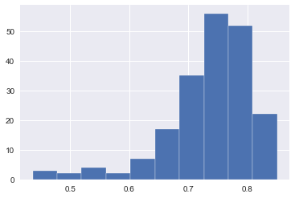

```
99.0 confidence interval 47.1% and 83.8%
```

```python
# plot scores
pyplot.hist(stats)
pyplot.show()
# confidence intervals
alpha = 0.99                             # for 95% confidence
p = ((1.0-alpha)/2.0) * 100              # tail regions on right and left .25 on each side indicated by P value (border)
lower = max(0.0, np.percentile(stats, p))
p = (alpha+((1.0-alpha)/2.0)) * 100
upper = min(1.0, np.percentile(stats, p))
print('%.1f confidence interval %.1f%% and %.1f%%' % (alpha*100, lower*100, upper*100))
```

**At 99% of confidence test accuracy will be between 47% and 83%**

**Displaying Various Models and theie train/test accuracies**

```python
def score_model(model,params,model_name):
    model_prod = make_pipeline( scl, smote,model(**params))
    model_prod.fit(X_train, y_train)
    y_pred = model_prod.predict(X_test)
    print(model_name)
    print('Train Accuracy: %.3f' % model_prod.score(X_train, y_train))
    print('Test Accuracy: %.3f' % model_prod.score(X_test, y_test))
    auc = roc_auc_score(y_test, y_pred)
    print('The auc score on the test set is {:.4f}.'.format(auc))
    print('f1_score',f1_score(y_pred,y_test))
    print(classification_report(y_test, y_pred))
```

```python
params=[{'random_state':7,'subsample_for_bin':160000,'num_leaves':32,'min_child_samples':350,
'learning_rate':0.006383753521596328,'is_unbalance':False,'boosting_type':'dart'},
{'base_estimator':DT,'random_state':7,'n_estimators':48,'max_samples':0.5,'max_features':0.5,'bootstrap_features':True,
                                                      'bootstrap':True},
{'random_state':7,'max_depth':2,'criterion':'gini','max_features':6,'min_samples_leaf':3,'n_estimators':47},
{'random_state':7,'C':0.0008557429665630984,'penalty':'l2','solver':'lbfgs'},
{'random_state':1,'criterion':'gini','max_depth':1,'max_features':1,'min_samples_leaf':4}
       ]

model=[lgb.LGBMClassifier,BaggingClassifier,RandomForestClassifier,LogisticRegression,DecisionTreeClassifier]
model_name=['Light Gradient Boosting','Bagging','Random Forest','Logistic Regression','Decison Tree']
for i,j,k in zip(model,params,model_name):
   score_model(i,j,k)
```

```
Light Gradient Boosting
Train Accuracy: 0.744
Test Accuracy: 0.754
The auc score on the test set is 0.6940.
f1_score 0.2564102564102564
              precision    recall  f1-score   support

          -1       0.97      0.76      0.85       439
           1       0.16      0.62      0.26        32

    accuracy                           0.75       471
   macro avg       0.56      0.69      0.55       471
weighted avg       0.91      0.75      0.81       471

Bagging
Train Accuracy: 0.742
Test Accuracy: 0.769
The auc score on the test set is 0.6296.
f1_score 0.2158273381294964
              precision    recall  f1-score   support

          -1       0.95      0.79      0.86       439
           1       0.14      0.47      0.22        32

    accuracy                           0.77       471
   macro avg       0.55      0.63      0.54       471
weighted avg       0.90      0.77      0.82       471

Random Forest
Train Accuracy: 0.811
Test Accuracy: 0.809
The auc score on the test set is 0.6367.
f1_score 0.23728813559322032
              precision    recall  f1-score   support

          -1       0.95      0.84      0.89       439
           1       0.16      0.44      0.24        32

    accuracy                           0.81       471
   macro avg       0.56      0.64      0.56       471
```

[output cut: 14 more lines]

```
weighted avg       0.90      0.74      0.80       471

Decison Tree
Train Accuracy: 0.727
Test Accuracy: 0.694
The auc score on the test set is 0.6187.
f1_score 0.19101123595505617
              precision    recall  f1-score   support

          -1       0.95      0.71      0.81       439
           1       0.12      0.53      0.19        32

    accuracy                           0.69       471
   macro avg       0.54      0.62      0.50       471
weighted avg       0.90      0.69      0.77       471
```

# Final Model

**Selecting Light GB as final model because it has good recall value for minority class and auc,f1 score is best compared to other models. Train and Test accuracy are equally balanced hence there is no overfitting in the data.**

```python
pipe_lgbc = make_pipeline(get_df,scl, smote,lgb.LGBMClassifier(random_state=7,subsample_for_bin=160000,num_leaves=32,min_child_samples=350,
                                                    learning_rate=0.006383753521596328,is_unbalance=False,boosting_type='dart'))
pipe_lgbc.fit(X_train, y_train)
```

```
Pipeline(steps=[('functiontransformer',
                 FunctionTransformer(func=<function pre_process at 0x00000285F3E335E8>)),
                ('standardscaler', StandardScaler()),
                ('smote', SMOTE(random_state=1)),
                ('lgbmclassifier',
                 LGBMClassifier(boosting_type='dart', is_unbalance=False,
                                learning_rate=0.006383753521596328,
                                min_child_samples=350, num_leaves=32,
                                random_state=7, subsample_for_bin=160000))])
```

**Pickling the final model**

```python
# Save to file in the current working directory
pkl_filename = "pickle_lightgbmmodel.pkl"
with open(pkl_filename, 'wb') as file:
    pickle.dump(pipe_lgbc, file)
```

```python
# Load from file
with open(pkl_filename, 'rb') as file:
    pickle_model = pickle.load(file)
```

**Reading Future Data.**

```python
df_Future=pd.read_excel('Future_predictions.xlsx')
```

**Predicting Output from our final selected model**

```python
pickle_model.predict(df_Future)
```

```
array([-1, -1,  1, -1, -1, -1, -1, -1, -1, -1, -1, -1, -1, -1,  1,  1, -1,
       -1], dtype=int64)
```

# **Conclusion**

- **Only 6% represents minority class so large collection of minority class might improve the model performance.**
- **Light GB model is final selected model because it has good recall value for minority class and balanced train/test error.**
- **Future data contains 18 rows and pickeld final model predicted output for 18 rows.**